# Kosis and Nhis comparison

# 데이터 step

## 종사자 규모 비교

```r
library(readxl)
library(tidyverse)
library(DT)
library(htmlTable)
```

Kosis 의 종사자와 Nhis 의 종사자를 비교하고자 한다. ### kosis 종사자 자료 우리 논문이 2006년부터 2015까지 추적 관찰한 것으로, 2012년의 임근금로자 중에 상용 근로자 수를 확인하여 비교하기로함. 사이트는 **https://kosis.kr/**임. [kosis](https://kosis.kr/)

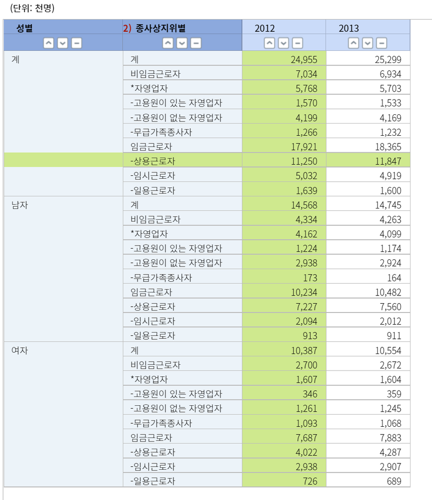

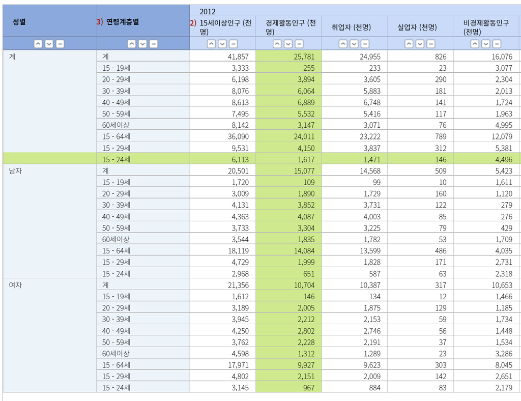

```r
employ_status = c("non-per", "permenent")
workers_employgp =c(7034+(5032+1639), 17921-(5032+1639))
agegp =c("others", "25-64")
workers_agegp=c(25781 -(24011-1617), 24011-1617)
dat1 = tibble(employ_status, workers_employgp)
dat2 = tibble(agegp, workers_agegp)
dat1= dat1 %>%
  mutate(ratio = workers_employgp/ sum(workers_employgp))
ratio1 = dat1%>% filter(employ_status == "permenent") %>% pull(ratio)
dat2 = dat2 %>%mutate(ratio = workers_agegp/sum(workers_agegp))
ratio2 = dat2%>% filter(agegp == "25-64") %>% pull(ratio)
dat1 %>% htmlTable()
```

|  | employ_status | workers_employgp | ratio |
| --- | --- | --- | --- |
| 1 | non-per | 13705 | 0.549188539370868 |
| 2 | permenent | 11250 | 0.450811460629132 |

```r
dat2 %>% htmlTable()
```

|  | agegp | workers_agegp | ratio |
| --- | --- | --- | --- |
| 1 | others | 3387 | 0.131375819401885 |
| 2 | 25-64 | 22394 | 0.868624180598115 |

```r
workers_kosis = 25781000 * ratio1 * ratio2
workers_kosis
```

```
## [1] 10095472
```

```r
workers_nhis = 10605077

error = round((workers_kosis - workers_nhis)/workers_kosis, 6 )*100
sprintf("%s%%", error)
```

```
## [1] "-5.0479%"
```

즉 오차는 -5.0479% 임.

## 암 발생자 수 비교

### kosis 암 발생자수 확인

우리 논문이 2006년부터 2015까지 추적 관찰한 것으로, 2012년의 5세별 암발생자 수를 확인하여 비교하기로함. 사이트는 **https://kosis.kr/**임. [kosis](https://kosis.kr/)

[figure not shown]

```r
library(readxl)
library(tidyverse)
library(DT)
library(htmlTable)
kosis = readxl::read_xlsx("data/cancers_kosis.xlsx")
head(kosis) %>% datatable()
```

|  | type | gender | age | case | crude_rate_per_100th |
| --- | --- | --- | --- | --- | --- |
| 1 | 모든암(C00-C96) | 계 | 25-29세 | 2793 | 82.4 |
| 2 |  |  | 30-34세 | 6184 | 154.19999999999999 |
| 3 |  |  | 35-39세 | 9647 | 234 |
| 4 |  |  | 40-44세 | 15112 | 331 |
| 5 |  |  | 45-49세 | 19137 | 461.4 |
| 6 |  |  | 50-54세 | 26984 | 629.1 |

데이터를 보기 좋게 가공합니다.

```r
kosis2 = kosis %>%
  fill(type, gender, .direction = "down") %>%
  mutate(type1 = str_replace_all(type, "\\([^)]*\\)", "")) %>%
  mutate(type2 = str_replace_all(type, ".*\\(|\\)", ""))  %>%
  mutate(agegp=str_sub(age, 1, 2)) %>%
  select(type1, type2, gender, agegp, case, crude_rate_per_100th)
head(kosis2) %>% htmlTable()
```

|  | type1 | type2 | gender | agegp | case | crude_rate_per_100th |
| --- | --- | --- | --- | --- | --- | --- |
| 1 | 모든암 | C00-C96 | 계 | 25 | 2793 | 82.4 |
| 2 | 모든암 | C00-C96 | 계 | 30 | 6184 | 154.19999999999999 |
| 3 | 모든암 | C00-C96 | 계 | 35 | 9647 | 234 |
| 4 | 모든암 | C00-C96 | 계 | 40 | 15112 | 331 |
| 5 | 모든암 | C00-C96 | 계 | 45 | 19137 | 461.4 |
| 6 | 모든암 | C00-C96 | 계 | 50 | 26984 | 629.1 |

nhis 데이터 불러오기

```r
base = readxl::read_xlsx("data/base.xlsx", sheet=1)
base %>%
  mutate(sex_type = ifelse(is.na(sex_type), 0, sex_type)) %>%
  filter(disease =="all cancer") %>%
  filter(sex_type ==0) %>%
  pull(pm)%>%sum(.) *1000000/12-> person_year
mean_follow_up_year = person_year /10786000
base_2009 = 10786000
```

위암을 중심으로 비교해 보겠다.

```r
kosis3 = kosis2 %>%
  rename(cr100 = crude_rate_per_100th) %>%
  filter(type2 =="C16") %>%
  filter(gender=="계") %>%
  mutate(pyear = as.numeric(case)/as.numeric(cr100)*100000) %>%
  mutate(tpyer = sum(pyear))
kosis3 %>% htmlTable()
```

|  | type1 | type2 | gender | agegp | case | cr100 | pyear | tpyer |
| --- | --- | --- | --- | --- | --- | --- | --- | --- |
| 1 | 위 | C16 | 계 | 25 | 85 | 2.5 | 3400000 | 30129950.2017537 |
| 2 | 위 | C16 | 계 | 30 | 314 | 7.8 | 4025641.02564103 | 30129950.2017537 |
| 3 | 위 | C16 | 계 | 35 | 667 | 16.2 | 4117283.95061728 | 30129950.2017537 |
| 4 | 위 | C16 | 계 | 40 | 1386 | 30.4 | 4559210.52631579 | 30129950.2017537 |
| 5 | 위 | C16 | 계 | 45 | 1999 | 48.2 | 4147302.90456431 | 30129950.2017537 |
| 6 | 위 | C16 | 계 | 50 | 3459 | 80.599999999999994 | 4291563.27543424 | 30129950.2017537 |
| 7 | 위 | C16 | 계 | 55 | 3800 | 117 | 3247863.24786325 | 30129950.2017537 |
| 8 | 위 | C16 | 계 | 60 | 4228 | 180.6 | 2341085.27131783 | 30129950.2017537 |

이 결과는 우리나라 전체 국민 중에 25세 미만, 65세 이상을 제외한 3000만 명을 1년간 추적했다는 결과이다. 우리는 1000만명을 추적관찰한 것임. 이에 따라 이의 약 1/3인 1000만 명을 평균 6.82년 추적 관찰한다면, 단순 계산으로는 몇몇이 발생하는지 추정해볼 수 있다.

```r
kosis4= kosis3 %>%
  mutate(predic_7years = as.numeric(case)*6.82/3) %>%
  mutate(total_observed_cancer = sum(predic_7years))
kosis4 %>% htmlTable()
```

|  | type1 | type2 | gender | agegp | case | cr100 | pyear | tpyer | predic_7years | total_observed_cancer |
| --- | --- | --- | --- | --- | --- | --- | --- | --- | --- | --- |
| 1 | 위 | C16 | 계 | 25 | 85 | 2.5 | 3400000 | 30129950.2017537 | 193.233333333333 | 36232.3866666667 |
| 2 | 위 | C16 | 계 | 30 | 314 | 7.8 | 4025641.02564103 | 30129950.2017537 | 713.826666666667 | 36232.3866666667 |
| 3 | 위 | C16 | 계 | 35 | 667 | 16.2 | 4117283.95061728 | 30129950.2017537 | 1516.31333333333 | 36232.3866666667 |
| 4 | 위 | C16 | 계 | 40 | 1386 | 30.4 | 4559210.52631579 | 30129950.2017537 | 3150.84 | 36232.3866666667 |
| 5 | 위 | C16 | 계 | 45 | 1999 | 48.2 | 4147302.90456431 | 30129950.2017537 | 4544.39333333333 | 36232.3866666667 |
| 6 | 위 | C16 | 계 | 50 | 3459 | 80.599999999999994 | 4291563.27543424 | 30129950.2017537 | 7863.46 | 36232.3866666667 |
| 7 | 위 | C16 | 계 | 55 | 3800 | 117 | 3247863.24786325 | 30129950.2017537 | 8638.66666666667 | 36232.3866666667 |
| 8 | 위 | C16 | 계 | 60 | 4228 | 180.6 | 2341085.27131783 | 30129950.2017537 | 9611.65333333333 | 36232.3866666667 |

```r
kosis_obs = kosis4 %>% pull(total_observed_cancer) %>% unique()
```

우리 nhis 데이터 중에 위암을 확인해 보자

```r
base1= base %>%
  mutate(sex_type = ifelse(is.na(sex_type), 0, sex_type)) %>%
  filter(disease =="60") %>%
  filter(sex_type ==0) %>%
  mutate(total_observed_cancer = sum(as.numeric(observed)))
nhis_obs=33410
base1 %>% select(-c(disease,disease,reference_observed_rate))
```

```
## # A tibble: 8 × 5
##   sex_type agegp    pm observed total_observed_cancer
##      <dbl> <dbl> <dbl> <chr>                    <dbl>
## 1        0     1 146.  551                      33410
## 2        0     2 153.  1284                     33410
## 3        0     3 156.  2707                     33410
## 4        0     4 139.  4150                     33410
## 5        0     5 122.  6013                     33410
## 6        0     6  93.1 7341                     33410
## 7        0     7  52.9 6251                     33410
## 8        0     8  29.5 5113                     33410
```

```r
error_cancer = sprintf("%.2f%%",  (nhis_obs -kosis_obs)/kosis_obs *100)
error_cancer
```

```
## [1] "-7.79%"
```

우리 연구에서 2009년부터 2015년 동안 발생한 총 위암의 수는 3.341^{4}이다. 이를 kosis 데이터와 비교하면 -7.79% 차이가 난다. 이는 error일 수도 건강근로자 효과 일 수도 있다.

# 정리